# Reproducible Research Peer Assessment 1

Mike Donnellan

Sunday, October 18, 2015

## Background

This R Markdown document was created to fulfil the requirements for Peer Assessment 1, the first project assignment of the Reproducible Research course offered via Coursera by Johns Hopkins University. Reproducible Research is course 5 of 9 in the Data Science Specialization.

Reviewers please note that the earlier authoring date for this file is the result of the author’s withdrawal from this course during the first attempt at completion.

### From the assignment itself

(available at https://class.coursera.org/repdata-032/human_grading/view/courses/975145/assessments/3/submissions):

This assignment makes use of data from a personal activity monitoring device. This device collects data at 5 minute intervals through out the day. The data consists of two months of data from an anonymous individual collected during the months of October and November, 2012 and include the number of steps taken in 5 minute intervals each day.

#### Data

The variables included in this dataset are:

- steps: Number of steps taking in a 5-minute interval (missing values are coded as NA)
- date: The date on which the measurement was taken in YYYY-MM-DD format
- interval: Identifier for the 5-minute interval in which measurement was taken

The dataset is stored in a comma-separated-value (CSV) file and there are a total of 17,568 observations in this dataset.

#### Tasks

Tasks performed to fulfil the requirements of this assignment include:

1. load the data and transform it into a usable format
2. calculate the total number of steps per day
3. create a histogram of the total number of steps per day
4. calculate and report the mean and median number of steps per day
5. Create a time series plot of the 5-minute interval (x-axis) and the average number of steps taken, averaged across all days (y-axis).
6. Determine and report which 5-minute interval, on average across all the days in the dataset, contains the maximum number of steps.
7. Calculate and report the total number of missing values in the dataset (i.e. the total number of rows with NAs).
8. Choose and implement a strategy for filling in all of the missing values in the dataset.
9. Create a histogram of the total number of steps taken each day and calculate and report the mean and median total number of steps taken per day, using the dataset with imputed values in place of the missing values in the original dataset.
10. Determine and report the differences between these results and those calculated in step 4 above, and describe the effect of imputing the missing values on the results.
11. Using the dataset with the filled-in missing values, create a new factor variable in the dataset with two levels - “weekday” and “weekend” indicating whether a given date is a weekday or weekend day, then create a panel plot containing a time series plot of the 5-minute interval (x-axis) and the average number of steps taken, averaged across all weekday days or weekend days (y-axis).

## The Work

### Task 1: Load and Transform the Data, Performing Prerequisites

Set the working directory (we assume this directory already exists, if not, please create it; code not supplied to avoid making changes to your system):

```r
setwd("C:/Users/mwdonnel/Documents/RCode/rr")
```

Now load the required libraries (if necessary, please install these libraries as may be required).

```r
library(knitr)
#set knitr to show results and cache already-calculated results)
opts_chunk$set(echo=TRUE,results="show",cache=TRUE)
library(dplyr)
```

```r
library(ggplot2)
library(lubridate)
```

Download the data and read it into a data frame.

```r
#put the data file download URL into a var
dlURL <- "https://d396qusza40orc.cloudfront.net/repdata%2Fdata%2Factivity.zip"

#put the destination path and filename into a var
dlFileName <- "repdata_data_activity.zip"

#download the data file
download.file(dlURL,dlFileName)

#decompress the data file
dataFileList <- unzip(dlFileName)

#the data file is activity.csv (determined by manual inspection of the .zip file),
#so we'll call read.csv to get the data into the environment.

dfActivity <- read.csv('activity.csv',
                        header = TRUE,
                        sep = ",",
                        colClasses=c("numeric", "character", "numeric")
                      )
```

#### Pre-process/transform the data to make it usable for analysis

Make the date column into an actual date, and since we need “interval” to be a factor, make it so.

```r
dfActivity$date <- as.Date(dfActivity$date, format = "%Y-%m-%d")
dfActivity$interval <- as.factor(dfActivity$interval)
```

### Task 2: Calculate Total Number of Steps Per Day

In SQL we might write something like SELECT SUM(Steps) FROM Activity GROUP BY Date. Here in R we’ll use aggregate:

```r
dfStepsGroupedByDay <- aggregate(steps ~ date, dfActivity, sum)
#now supply the column names:
colnames(dfStepsGroupedByDay) <- c("Date","TotalStepsOnDate")
```

### Task 3: Plot Histogram of Total Number of Steps Per Day

We’ll use ggplot2 to create the histogram of steps per day:

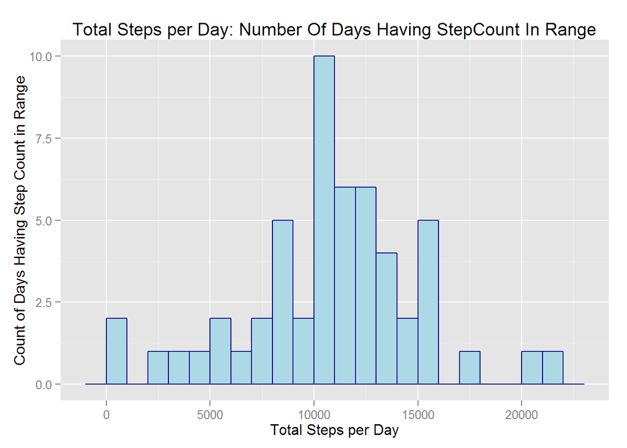

```r
ggplot(dfStepsGroupedByDay, aes(x = TotalStepsOnDate)) +
       geom_histogram(color="darkblue", fill = "lightblue", binwidth = 1000) +
        labs(title="Total Steps per Day: Number Of Days Having StepCount In Range",
             x = "Total Steps per Day", y = "Count of Days Having Step Count in Range")
```

### Task 4: Calculate and Report Mean and Median Number of Steps Per Day

Straightforward, recalling that we have empty values:

```r
TotalStepsOnDateMean   <- mean(dfStepsGroupedByDay$TotalStepsOnDate, na.rm=TRUE)
TotalStepsOnDateMedian   <- median(dfStepsGroupedByDay$TotalStepsOnDate, na.rm=TRUE)
cat("Mean of total steps per day: ", TotalStepsOnDateMean, "\n")
```

```
## Mean of total steps per day:  10766.19
```

```r
cat("Median of total steps per day: ", TotalStepsOnDateMedian, "\n")
```

```
## Median of total steps per day:  10765
```

### Task 5: Create a time series plot of the 5-minute interval (x-axis) and the average number of steps taken, averaged across all days (y-axis)

```r
dfStepsGroupedByInterval <- aggregate(as.integer(dfActivity$steps),
                                      by = list(interval = as.integer(dfActivity$interval)),
                                      FUN=mean,
                                      na.rm=TRUE
                                     )

#now supply the column names and other text:
colnames(dfStepsGroupedByInterval) <- c("IntervalNumber","TotalStepsInInterval")
#examine our result
head(dfStepsGroupedByInterval)
```

```
##   IntervalNumber TotalStepsInInterval
## 1              1            1.7169811
## 2              2            0.3396226
## 3              3            0.1320755
## 4              4            0.1509434
## 5              5            0.0754717
## 6              6            2.0943396
```

```r
str(dfStepsGroupedByInterval)
```

```
## 'data.frame':    288 obs. of  2 variables:
##  $ IntervalNumber      : int  1 2 3 4 5 6 7 8 9 10 ...
##  $ TotalStepsInInterval: num  1.717 0.3396 0.1321 0.1509 0.0755 ...
```

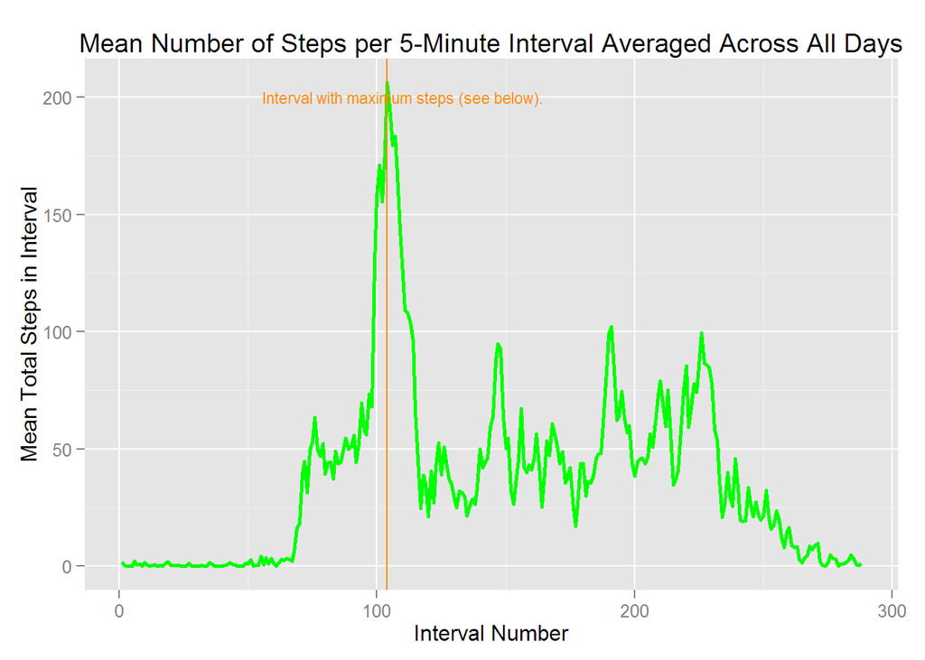

```r
#draw the graph
ggplot(dfStepsGroupedByInterval, aes(x=IntervalNumber, y=TotalStepsInInterval)) +
        geom_line(color="green", size=1) +
        geom_vline(color = "darkorange",
                   xintercept = which.max(dfStepsGroupedByInterval$TotalStepsInInterval)) +
        annotate("text",x=110, y=200, label="Interval with maximum steps (see below).",
                 size=3, color="darkorange") +
        labs(title="Mean Number of Steps per 5-Minute Interval Averaged Across All Days",
             x="Interval Number", y="Mean Total Steps in Interval")
```

### Task 6: Determine and report which 5-minute interval, on average across all the days in the dataset, contains the maximum number of steps

Once again, straightforward:

```r
maxInterval <- dfStepsGroupedByInterval[which.max(dfStepsGroupedByInterval$TotalStepsInInterval),]
numHours <- ((maxInterval$IntervalNumber - 1) * 5) %/% 60
numMinutes <- ((maxInterval$IntervalNumber - 1) * 5) %% 60
cat("The interval with the maximum average number of steps is ",
    maxInterval$IntervalNumber," and the maximum average number of steps is: ",
    maxInterval$TotalStepsInInterval,
    ".\n", "Interval 104 begins at ",numHours," hours ", numMinutes,
    "minutes into a given day.\nPerhaps people take more steps, on average, as they begin their day, travel to work or school, and so on.\n")
```

```
## The interval with the maximum average number of steps is  104  and the maximum average number of steps is:  206.1698 .
##  Interval 104 begins at  8  hours  35 minutes into a given day.
## Perhaps people take more steps, on average, as they begin their day, travel to work or school, and so on.
```

### Task 7: Calculate and report the total number of missing values in the dataset (i.e. the total number of rows with NAs)

Straightforward:

```r
cat("The number of missing values in the input data set is: ", sum(is.na(dfActivity$steps)), ".\n")
```

```
## The number of missing values in the input data set is:  2304 .
```

### Task 8: Choose and implement a strategy for filling in all of the missing values in the dataset

Here we choose the cheap solution, being out of time. We’ll stick the means in place of the NAs, using an elegant and “R-like” solution found on stackoverflow (http://stackoverflow.com/questions/24847299/using-ifelse-to-replace-nas-in-one-data-frame-by-referencing-another-data-fram).

The “strategy,” to dignify it with that name, is for each interval with value NA, to replace it with the average number of steps for that particular interval, taken across all days in the data set.

```r
#start clean with original data for imputation

dfActivityImputed <- read.csv('activity.csv',
                        header = TRUE,
                        sep = ",",
                        colClasses=c("numeric", "character", "numeric")
                      )

# note that in this calculation we DO NOT make interval into a factor

dfStepsGroupedByIntervalImputed <- aggregate(as.integer(dfActivityImputed$steps),
                                      by = list(interval = as.integer(dfActivityImputed$interval)),
                                      FUN=mean,
                                      na.rm=TRUE
                                     )

colnames(dfStepsGroupedByIntervalImputed) <- c("IntervalNumber","TotalStepsInInterval")

dfActivityImputed$steps[is.na(dfActivityImputed$steps)] <- dfStepsGroupedByIntervalImputed$TotalStepsInInterval[match(dfActivityImputed$interval[is.na(dfActivityImputed$steps)],dfStepsGroupedByIntervalImputed$IntervalNumber)]
head(dfActivityImputed)
```

```
##       steps       date interval
## 1 1.7169811 2012-10-01        0
## 2 0.3396226 2012-10-01        5
## 3 0.1320755 2012-10-01       10
## 4 0.1509434 2012-10-01       15
## 5 0.0754717 2012-10-01       20
## 6 2.0943396 2012-10-01       25
```

```r
head(dfStepsGroupedByIntervalImputed)
```

```
##   IntervalNumber TotalStepsInInterval
## 1              0            1.7169811
## 2              5            0.3396226
## 3             10            0.1320755
## 4             15            0.1509434
## 5             20            0.0754717
## 6             25            2.0943396
```

```r
str(dfActivityImputed)
```

```
## 'data.frame':    17568 obs. of  3 variables:
##  $ steps   : num  1.717 0.3396 0.1321 0.1509 0.0755 ...
##  $ date    : chr  "2012-10-01" "2012-10-01" "2012-10-01" "2012-10-01" ...
##  $ interval: num  0 5 10 15 20 25 30 35 40 45 ...
```

```r
str(dfStepsGroupedByIntervalImputed)
```

```
## 'data.frame':    288 obs. of  2 variables:
##  $ IntervalNumber      : int  0 5 10 15 20 25 30 35 40 45 ...
##  $ TotalStepsInInterval: num  1.717 0.3396 0.1321 0.1509 0.0755 ...
```

```r
cat("The number of missing values in the input data set is: ", sum(is.na(dfActivityImputed)), ".\n")
```

```
## The number of missing values in the input data set is:  0 .
```

### Task 9: Create a histogram of the total number of steps taken each day and calculate and report the mean and median total number of steps taken per day, using the dataset with imputed values in place of the missing values in the original dataset.

Same as above with different data frame:

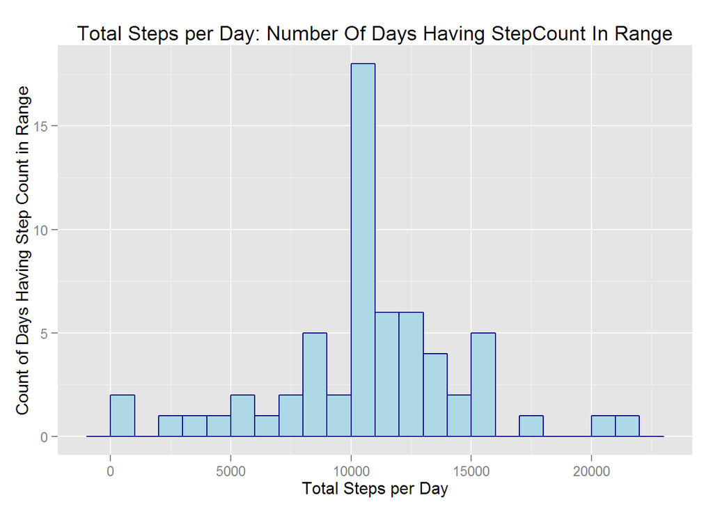

```r
dfStepsGroupedByDayFilled <- aggregate(steps ~ date, dfActivityImputed, sum)
#now supply the column names:
colnames(dfStepsGroupedByDayFilled) <- c("Date","TotalStepsOnDate")

ggplot(dfStepsGroupedByDayFilled, aes(x = TotalStepsOnDate)) +
       geom_histogram(color="darkblue", fill = "lightblue", binwidth = 1000) +
        labs(title="Total Steps per Day: Number Of Days Having StepCount In Range",
             x = "Total Steps per Day", y = "Count of Days Having Step Count in Range")
```

```r
TotalStepsOnDateMeanFilled   <- mean(dfStepsGroupedByDayFilled$TotalStepsOnDate, na.rm=TRUE)
TotalStepsOnDateMedianFilled   <- median(dfStepsGroupedByDayFilled$TotalStepsOnDate, na.rm=TRUE)

cat("Mean of total steps per day with imputed data: ", TotalStepsOnDateMeanFilled, "\n")
```

```
## Mean of total steps per day with imputed data:  10766.19
```

```r
cat("Median of total steps per day with imputed data: ", TotalStepsOnDateMedianFilled, "\n")
```

```
## Median of total steps per day with imputed data:  10766.19
```

### Task 10: Determine and report the differences between these results and those calculated in step 4 above, and describe the effect of imputing the missing values on the results.

```r
cat("Mean of total steps per day for original dataset: ", TotalStepsOnDateMean, "\n")
```

```
## Mean of total steps per day for original dataset:  10766.19
```

```r
cat("Median of total steps per day for original dataset: ", TotalStepsOnDateMedian, "\n\n")
```

```
## Median of total steps per day for original dataset:  10765
```

```r
cat("Mean of total steps per day for dataset with imputed values: ",
    TotalStepsOnDateMeanFilled, "\n")
```

```
## Mean of total steps per day for dataset with imputed values:  10766.19
```

```r
cat("Median of total steps per day for datasetwith imputed values: ",
    TotalStepsOnDateMedianFilled, "\n\n")
```

```
## Median of total steps per day for datasetwith imputed values:  10766.19
```

```r
cat("Difference between the filled dataset and the original for mean: ",
        TotalStepsOnDateMeanFilled - TotalStepsOnDateMean, "\n")
```

```
## Difference between the filled dataset and the original for mean:  0
```

```r
cat("Difference between the filled dataset and the original for median: ",
        TotalStepsOnDateMedianFilled - TotalStepsOnDateMedian, "\n")
```

```
## Difference between the filled dataset and the original for median:  1.188679
```

### Task 11: Using the dataset with the filled-in missing values, create a new factor variable in the dataset with two levels - “weekday” and “weekend” indicating whether a given date is a weekday or weekend day, then create a panel plot containing a time series plot of the 5-minute interval (x-axis) and the average number of steps taken, averaged across all weekday days or weekend days (y-axis).

```r
WeekDayInputData <- function(InputData) {
    WeekDayInputData <- aggregate(InputData$steps, by=list(interval = InputData$interval),
                          FUN=mean, na.rm=TRUE)
    #convert the factor interval number to an integer so we can graph it
    WeekDayInputData$interval <- as.integer(WeekDayInputData$interval)
    colnames(WeekDayInputData) <- c("interval", "steps")
    WeekDayInputData
}

SplitIntoWeekDayAndWeekEnd <- function(InputData) {
    InputData$weekday <-
            as.factor(weekdays(InputData$date)) # weekdays
    WE_InputData <- subset(InputData, weekday %in% c("Saturday","Sunday"))
    WD_InputData <- subset(InputData, !weekday %in% c("Saturday","Sunday"))

    WE_steps <- WeekDayInputData(WE_InputData)
    WD_steps <- WeekDayInputData(WD_InputData)

    WE_steps$dayofweek <- rep("weekend", nrow(WE_steps))
    WD_steps$dayofweek <- rep("weekday", nrow(WD_steps))

    SplitIntoWeekDayAndWeekEnd <- rbind(WE_steps, WD_steps)
    SplitIntoWeekDayAndWeekEnd$dayofweek <- as.factor(SplitIntoWeekDayAndWeekEnd$dayofweek)
    SplitIntoWeekDayAndWeekEnd
}

#weekday function requires its input to be a date data type
dfActivityImputed$date <- as.Date(dfActivityImputed$date, format = "%Y-%m-%d")
dfActivityImputed$interval <- as.factor(dfActivityImputed$interval)

InputDataByDayType <- SplitIntoWeekDayAndWeekEnd(dfActivityImputed)

str(InputDataByDayType)
```

```
## 'data.frame':    576 obs. of  3 variables:
##  $ interval : int  1 2 3 4 5 6 7 8 9 10 ...
##  $ steps    : num  0.21462 0.04245 0.01651 0.01887 0.00943 ...
##  $ dayofweek: Factor w/ 2 levels "weekday","weekend": 2 2 2 2 2 2 2 2 2 2 ...
```

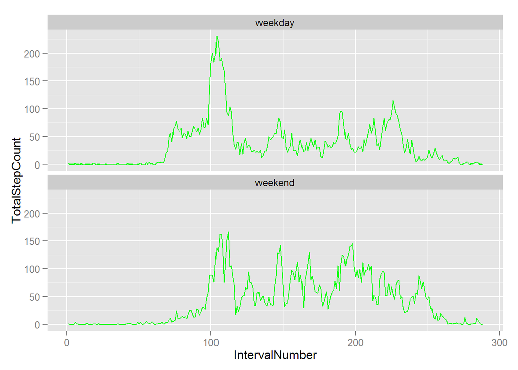

```r
ggplot(InputDataByDayType, aes(x=interval, y=steps)) +
        geom_line(color="green") +
        facet_wrap(~ dayofweek, nrow=2, ncol=1) +
        labs(x="IntervalNumber", y="TotalStepCount")
```

These results show a significant difference in average activity patterns between weekdays and weekends. While weekends still show a morning peak, the peak is bifurcated, and is both later and lower than that for weekdays.  
Activity is more evenly spread throughout weekend days as compared with weekdays, perhaps reflecting the lack of confinement to a workplace on weekends. Moreover, the final activity local maximum for weekend days is later than that for weekdays. One might conjecture that this final peak is associated with recreational activities of various kinds.